# Exploratory Analysis On $\textrm{PM}_{2.5}$ Database

George Papadopoulos

pgeorgios8@gmail.com

2023-11-22

# Introduction

Fine particulate matter (PM2.5) is an ambient air pollutant for which there is strong evidence that it is harmful to human health. In the United States, the Environmental Protection Agency (EPA) is tasked with setting national ambient air quality standards for fine PM and for tracking the emissions of this pollutant into the atmosphere. Approximatly every 3 years, the EPA releases its database on emissions of PM2.5. This database is known as the National Emissions Inventory (NEI). You can read more information about the NEI at the EPA National Emissions Inventory web site.

For each year and for each type of PM source, the NEI records how many tons of PM2.5 were emitted from that source over the course of the entire year. The data that we will use for this assignment are for 1999, 2002, 2005, and 2008.

# Preprocessing

## Getting The Data

The data we will use can be found [here](https://d396qusza40orc.cloudfront.net/exdata%2Fdata%2FNEI_data.zip), the zip file contains two files.

```r
download.file("https://d396qusza40orc.cloudfront.net/exdata%2Fdata%2FNEI_data.zip","file.zip")
unzip("file.zip")
```

## Load Data

We will load the data using the command **readRDS**.

```r
NEI <- readRDS("summarySCC_PM25.rds")
SCC <- readRDS("Source_Classification_Code.rds")
```

## Variables Explanation

After the download and the unzip operation we see two **rds** type files in the working folder.

1. PM2.5 Emissions Data $\color{red}{\verb|summarySCC_PM25.rds|}$: This file contains a data frame with all of the PM2.5 emissions data for 1999, 2002, 2005, and 2008. For each year, the table contains number of tons of PM2.5 emitted from a specific type of source for the entire year. Here are the first few rows:

```r
head(NEI,5)
```

```
    fips      SCC Pollutant Emissions  type year
4  09001 10100401  PM25-PRI    15.714 POINT 1999
8  09001 10100404  PM25-PRI   234.178 POINT 1999
12 09001 10100501  PM25-PRI     0.128 POINT 1999
16 09001 10200401  PM25-PRI     2.036 POINT 1999
20 09001 10200504  PM25-PRI     0.388 POINT 1999
```

- $\color{red}{\verb|fips|}$: A five-digit number (represented as a string) indicating the U.S. county
- $\color{red}{\verb|SCC|}$: The name of the source as indicated by a digit string (see source code classification table)
- $\color{red}{\verb|Pollutant|}$: A string indicating the pollutant
- $\color{red}{\verb|Emissions|}$: Amount of PM2.5 emitted, in tons
- $\color{red}{\verb|type|}$: The type of source (point, non-point, on-road, or non-road)
- $\color{red}{\verb|year|}$: The year of emissions recorded
2. Source Classification Code Table $\color{red}{\verb|Source_Classification_Code.rds|}$: This table provides a mapping from the SCC digit strings in the Emissions table to the actual name of the PM2.5 source. The sources are categorized in a few different ways from more general to more specific and you may choose to explore whatever categories you think are most useful. For example, source “10100101” is known as “Ext Comb /Electric Gen /Anthracite Coal /Pulverized Coal”.

### Preprocess Data

Search for ‘NA’.

```r
sum(is.na(NEI))
```

```
[1] 0
```

# Exploratory Analysis

## Goal Of The Report

The overall goal of this assignment is to explore the National Emissions Inventory database and see what it reports about fine particulate matter pollution in the United states over the 10-year period 1999–2008. You may use any R package you want to support your analysis.

## Questions Answered Via Plots

### Question 1

**Have total emissions from PM2.5 decreased in the United States from 1999 to 2008? Using the base plotting system, make a plot showing the total PM2.5 emission from all sources for each of the years 1999, 2002, 2005, and 2008.**

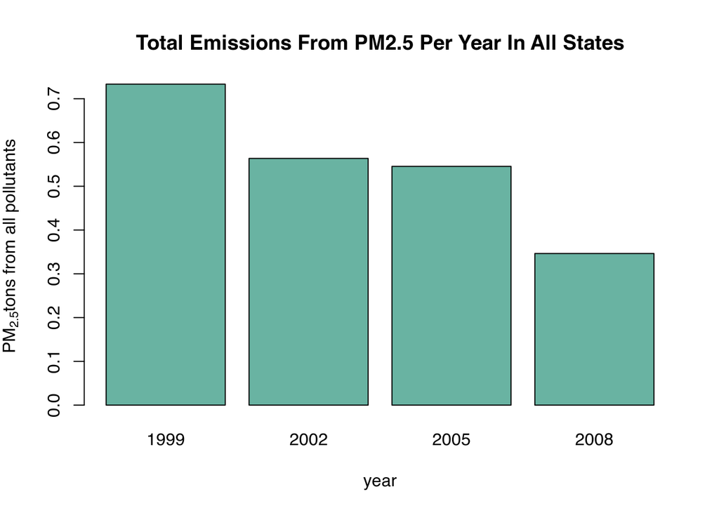

```r
library(dplyr,warn.conflicts = FALSE)
options(dplyr.summarise.inform = FALSE)
NEI$Emissions <- NEI$Emissions / 10e6
height <- NEI %>% group_by(year) %>% summarise(total = sum(Emissions))
barplot(as.matrix(height)[,2],xlab = 'year',ylab = expression(paste(PM[2.5],
                                                                    'tons from all pollutants')),
        names = as.matrix(height)[,1],
        col = "#69b3a2",main = "Total Emissions From PM2.5 Per Year In All States")
```

```r
rm(height)
```

### Question 2

**Have total emissions from PM2.5 decreased in the Baltimore City, Maryland $\color{red}{\verb|fips == "24510"|}$ from 1999 to 2008? Use the base plotting system to make a plot answering this question.**

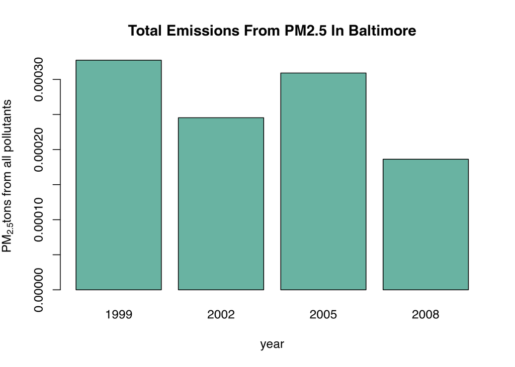

```r
height <- NEI %>% filter(fips == "24510") %>% group_by(year) %>% summarise(sum(Emissions))
barplot(as.matrix(height)[,2],xlab = 'year',ylab = expression(paste(PM[2.5],
                                                                    'tons from all pollutants')),
        names = as.matrix(height)[,1],
        col = "#69b3a2")
title(main = "Total Emissions From PM2.5 In Baltimore")
```

```r
rm(height)
```

### Question 3

**Of the four types of sources indicated by the $\color{red}{\verb|type|}$ type (point, nonpoint, onroad, nonroad) variable, which of these four sources have seen decreases in emissions from 1999–2008 for Baltimore City? Which have seen increases in emissions from 1999–2008? Use the ggplot2 plotting system to make a plot answer this question.**

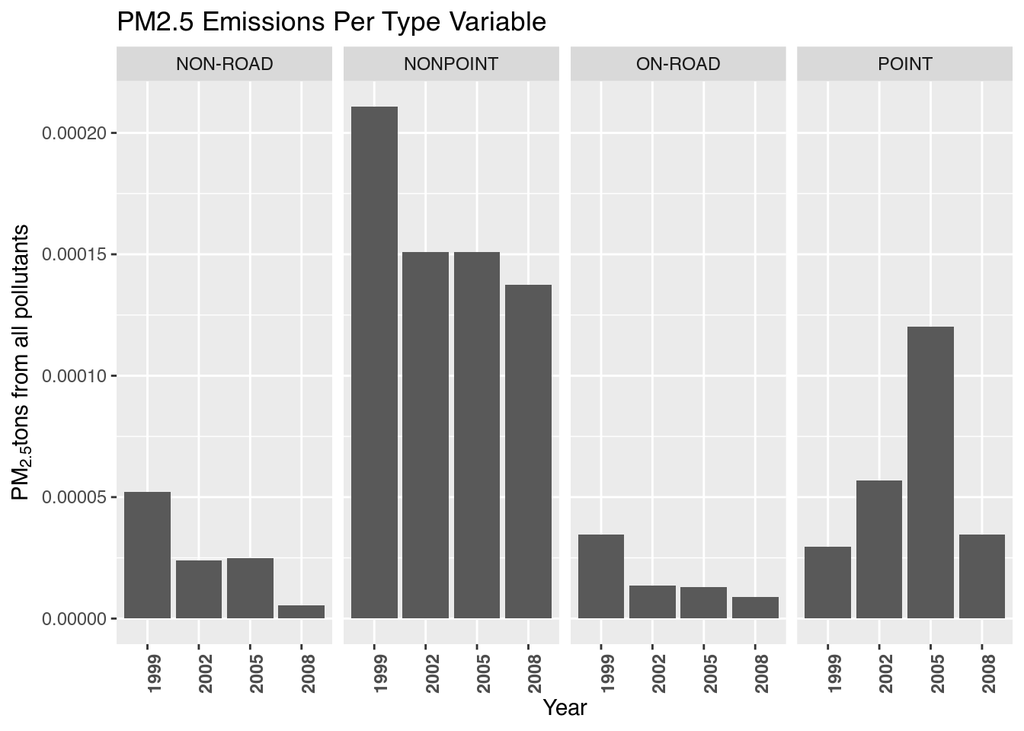

```r
library(ggplot2)
data <- NEI %>% filter(fips == '24510') %>% group_by(type,year) %>% summarise(total = sum(Emissions))
g <- ggplot(data,aes(y = total,x = as.factor(year))) +
  geom_bar(stat = 'identity') + facet_grid(. ~ type)
g + theme(axis.text.x = element_text(face = "bold", angle = 90)) + xlab("Year") +
  ylab(expression(paste(PM[2.5],'tons from all pollutants'))) +
  ggtitle("PM2.5 Emissions Per Type Variable")
```

```r
rm(data)
rm(g)
```

### Question 4

**Across the United States, how have emissions from coal combustion-related sources changed from 1999–2008?**

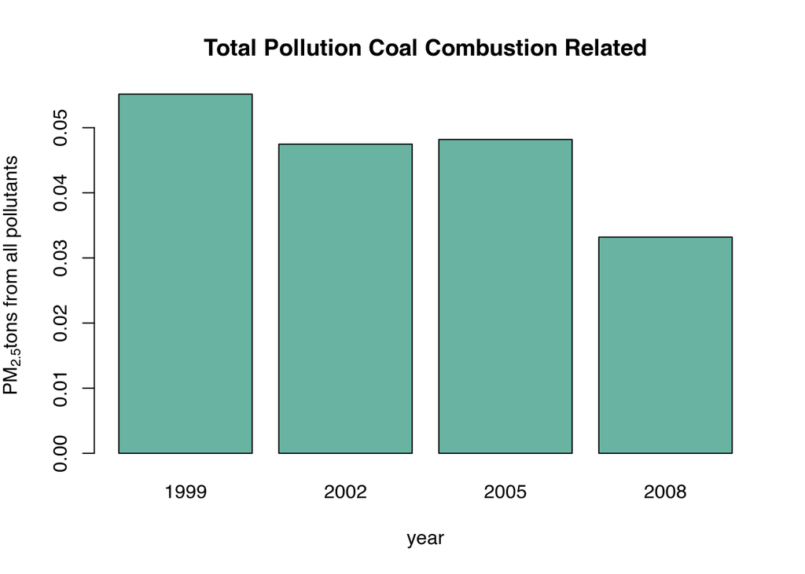

```r
comb <- grepl("comb",SCC$SCC.Level.One, ignore.case = TRUE)
coal <- grepl("coal",SCC$SCC.Level.Four,ignore.case = TRUE)
both <- SCC[comb & coal,]$SCC
data <- NEI[NEI$SCC %in% both,] %>% group_by(year) %>% summarise(total = sum(Emissions))
barplot(data$total,xlab = 'year',ylab = expression(paste(PM[2.5],'tons from all pollutants')),
        names = data$year,
        col = "#69b3a2",main = "Total Pollution Coal Combustion Related")
```